# Module4_USL_Part1

### Introduction, Packages, and Data Loading

This project aims to classify BBC news articles into one of several categories using text classification techniques. It leverages common natural language processing (NLP) steps, feature extraction, dimensionality reduction, and machine learning models to make predictions on unlabeled articles.

The Python script begins by importing necessary libraries, including:

Pandas and NumPy for data manipulation.

Matplotlib and Seaborn for data visualization.

NLTK for natural language processing tasks such as tokenization and stop word removal.

Scikit-learn for feature engineering (TfidfVectorizer), dimensionality reduction (TruncatedSVD), modeling, and evaluation.

The dataset is read from CSV files: BBCTrain.csv (labeled data) and BBCTest.csv (unlabeled data for submission).

```python
# BBC News Text Classification Project

import pandas as pd
import numpy as np
import matplotlib.pyplot as plt
from collections import Counter
import nltk
from nltk.corpus import stopwords
from nltk.tokenize import word_tokenize
from sklearn.feature_extraction.text import TfidfVectorizer
from sklearn.svm import SVC
from sklearn.ensemble import RandomForestClassifier, GradientBoostingClassifier
from sklearn.metrics import confusion_matrix, ConfusionMatrixDisplay, accuracy_score
from sklearn.model_selection import train_test_split, GridSearchCV
from sklearn.decomposition import TruncatedSVD
import seaborn as sns
from wordcloud import WordCloud
from sklearn.decomposition import TruncatedSVD
from sklearn.cluster import KMeans
from sklearn.metrics import accuracy_score, confusion_matrix
from sklearn.preprocessing import LabelEncoder
import matplotlib.pyplot as plt
from sklearn.utils import shuffle
import os


# read data
train_df = pd.read_csv('data/BBCTrain.csv')
test_data = pd.read_csv('data/BBCTest.csv')

# train_data = pd.read_csv('/kaggle/input/learn-ai-bbc/BBC News Train.csv')
# test_data = pd.read_csv('/kaggle/input/learn-ai-bbc/BBC News Test.csv')
```

### Exploratory Data Analysis (EDA)

The EDA step explores the structure and properties of the dataset:

```
Dataset Info:
<class 'pandas.core.frame.DataFrame'>
RangeIndex: 1490 entries, 0 to 1489
Data columns (total 3 columns):
 #   Column     Non-Null Count  Dtype
---  ------     --------------  -----
 0   ArticleId  1490 non-null   int64
 1   Text       1490 non-null   object
 2   Category   1490 non-null   object
dtypes: int64(1), object(2)
memory usage: 35.1+ KB
None
Missing Values:
ArticleId    0
Text         0
Category     0
dtype: int64
```

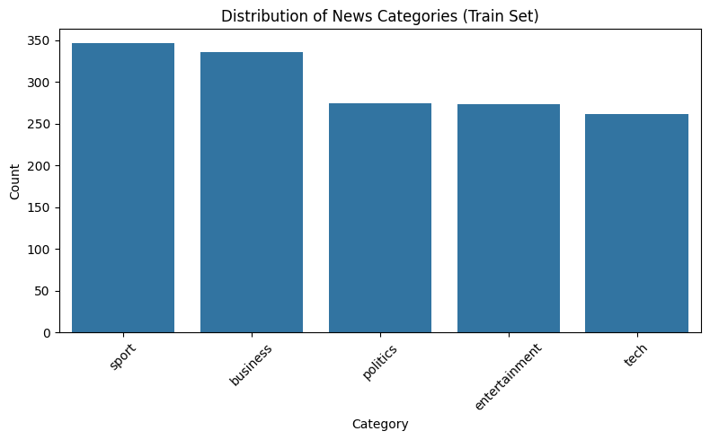

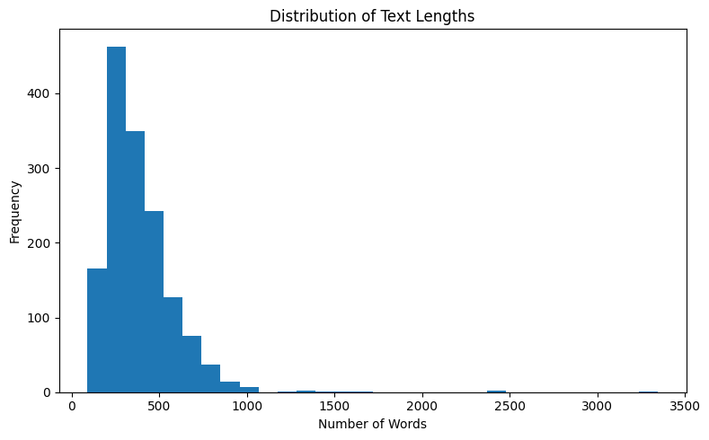

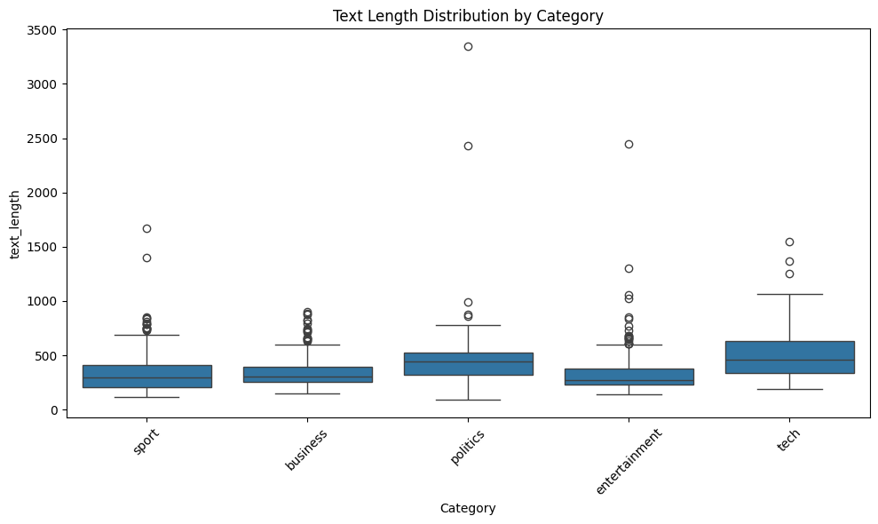

```
Average number of words per category:
Category
tech             501.858238
politics         449.689781
sport            335.346821
business         334.169643
entertainment    333.912088
Name: text_length, dtype: float64
```

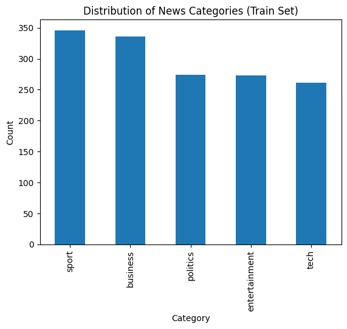

```python
# EDA
# Show basic info about the dataset
print("Dataset Info:")
print(train_df.info())

# Check for missing values
print("Missing Values:")
print(train_df.isnull().sum())

# 1. Bar plot for category distribution
plt.figure(figsize=(8, 5))
sns.countplot(x='Category', data=train_df, order=train_df['Category'].value_counts().index)
plt.title('Distribution of News Categories (Train Set)')
plt.xlabel('Category')
plt.ylabel('Count')
plt.xticks(rotation=45)
plt.tight_layout()
plt.show()

# 2. Histogram of text lengths
train_df['text_length'] = train_df['Text'].apply(lambda x: len(str(x).split()))
plt.figure(figsize=(8, 5))
plt.hist(train_df['text_length'], bins=30)
plt.title('Distribution of Text Lengths')
plt.xlabel('Number of Words')
plt.ylabel('Frequency')
plt.tight_layout()
plt.show()

# 3. Boxplot of text lengths per category
plt.figure(figsize=(10, 6))
sns.boxplot(x='Category', y='text_length', data=train_df, order=train_df['Category'].value_counts().index)
plt.title('Text Length Distribution by Category')
plt.xticks(rotation=45)
plt.tight_layout()
plt.show()

# 4. Average number of words per category
avg_words = train_df.groupby('Category')['text_length'].mean().sort_values(ascending=False)
print("Average number of words per category:")
print(avg_words)

# 5. Distribution of News Categories
train_df['Category'].value_counts().plot(kind='bar')
plt.title('Distribution of News Categories (Train Set)')
plt.xlabel('Category')
plt.ylabel('Count')
plt.show()
```

### Cleaning and Removing Stop Words

To prepare the raw text for modeling, a cleaning function is applied:

#### Stop Words:

The standard English stopwords from NLTK are extended with custom tokens, punctuation, numbers, and frequent but uninformative words (e.g., "said", "report", "percent").

#### Tokenization and Filtering:

Each text entry is:

- Lowercased
- Tokenized into words
- Filtered to keep only alphabetic tokens longer than two characters
- Stripped of all stop words

The cleaned version of the text is stored in a new column clean_text in both datasets. This significantly reduces noise and prepares the text for vectorization.

Additionally, this part of the EDA makes more sense after the data has been cleaned

- For each news category, the top 10 most common words are printed, giving insight into category-specific vocabulary.
- Average Words per Category: A printed summary reveals the average text length for each category, helping understand category-wise verbosity.
- Word Clouds per Category: Each category has a corresponding word cloud showing its most frequent terms, aiding in understanding topical differences between categories.

```
Top words per category:
business: [('market', 278), ('firm', 261), ('growth', 257), ('company', 252), ('economy', 233), ('government', 214), ('bank', 206), ('economic', 202), ('sales', 200), ('may', 182)]
tech: [('mobile', 326), ('technology', 303), ('users', 268), ('software', 265), ('use', 257), ('music', 254), ('net', 247), ('digital', 244), ('many', 236), ('phone', 225)]
politics: [('labour', 488), ('government', 462), ('election', 396), ('blair', 390), ('party', 362), ('minister', 284), ('brown', 261), ('told', 219), ('plans', 212), ('public', 204)]
sport: [('game', 351), ('england', 327), ('win', 292), ('world', 261), ('time', 223), ('back', 220), ('players', 208), ('cup', 204), ('ireland', 194), ('play', 190)]
entertainment: [('film', 553), ('best', 404), ('music', 255), ('show', 220), ('awards', 184), ('actor', 167), ('number', 165), ('band', 162), ('director', 155), ('award', 145)]
```

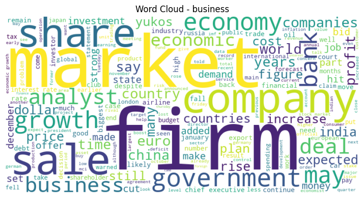

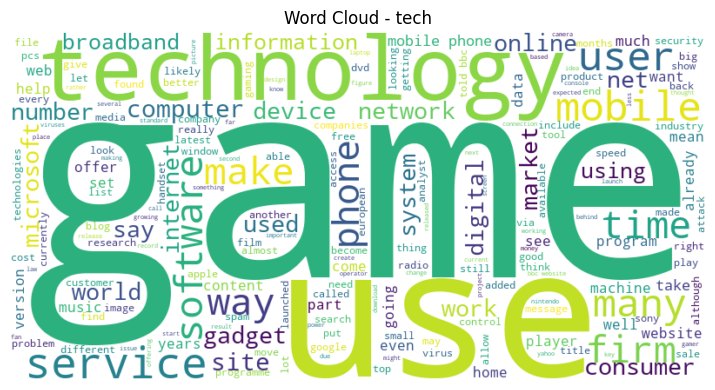

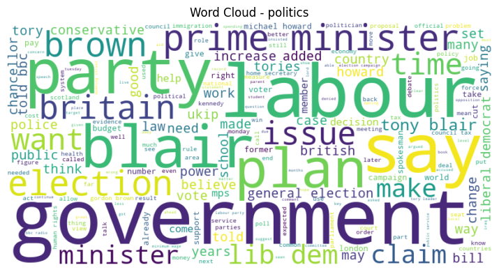

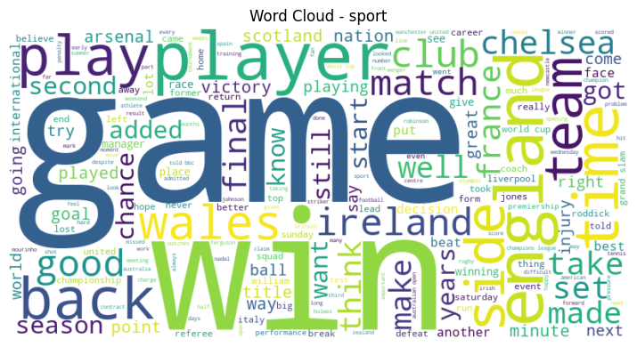

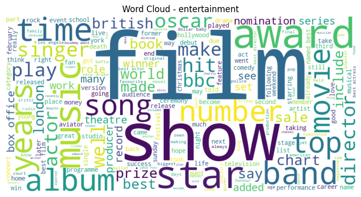

```python
# Clean
nltk.download('stopwords')
nltk.download('punkt')

stop_words = set(stopwords.words('english'))

extra_stopwords = {
    '-', '--', '–', '—', '‘', '’', '`', '``', "''", "'", '"', "“", "”", '...', '..', '.', ',', ';', ':', '?',
    '!', '/', '\\', '|', '[', ']', '{', '}', '(', ')', '<', '>', '*', '&', '^', '%', '$', '#', '@', '~', '=', '+', '_', # punctuations
    '0', '1', '2', '3', '4', '5', '6', '7', '8', '9', '10', '100', 'thousand', 'million','billion','one', 'two', 'three',
    'four', 'five','six', 'seven', 'eight', 'nine', 'ten', # numbers
    'said', 'mr', 'mrs', 'ms', 'miss', 'dr', 'prof', 'would', 'could', 'also', 'new', 'old', 'first', 'last',
    'today', 'yesterday', 'year', 'day', 'week', 'month', 'ago', 'past', 'future', 'people', 'man', 'woman', 'child',
    'children', 'men', 'women', 'person', 'group','percent', 'per', 'cent', 'according', 'including',
    'among', 'around', 'within', 'without', 'across', 'whether', 'u.s.', 'us', 'canada', 'america', 'uk', 'europe',
    'north', 'south', 'east', 'west', 'report', 'reports', 'reported',  'example', 'story', 'news', 'photo', 'video', "n't", "'s", "'ve", "'re" # Other words
}

stop_words = stop_words.union(extra_stopwords)

def clean_text(text):
    text = str(text).lower()
    tokens = word_tokenize(text)
    tokens = [word for word in tokens if word.isalpha()]
    tokens = [word for word in tokens if word not in stop_words and len(word) > 2]
    return " ".join(tokens)

train_df['clean_text'] = train_df['Text'].apply(clean_text)
test_data['clean_text'] = test_data['Text'].apply(clean_text)

# 6. Top 10 most common words per category
print("\nTop words per category:")
for cat in train_df['Category'].unique():
    words = " ".join(train_df[train_df['Category'] == cat]['clean_text']).split()
    common_words = Counter(words).most_common(10)
    print(f"{cat}: {common_words}")

# 7. Word cloud per category
categories = train_df['Category'].unique()
for cat in categories:
    plt.figure(figsize=(8, 4))
    text = " ".join(train_df[train_df['Category'] == cat]['clean_text'])
    wordcloud = WordCloud(width=800, height=400, background_color='white').generate(text)
    plt.imshow(wordcloud, interpolation='bilinear')
    plt.axis('off')
    plt.title(f'Word Cloud - {cat}')
    plt.tight_layout()
    plt.show()
```

### SVD Transformation and Encoding

This section transforms the cleaned text into a machine-readable format and reduces its dimensionality:

##### TF-IDF Vectorization

TfidfVectorizer converts the cleaned text into a matrix of TF-IDF features, capturing term importance while down-weighting common terms. A maximum of 3000 features is retained to balance richness and sparsity.

##### Train-Validation Split

The labeled dataset is split into training and validation sets (80/20 split).

##### Truncated SVD (Latent Semantic Analysis)

Given that TF-IDF matrices are sparse and high-dimensional, Truncated Singular Value Decomposition (SVD) is applied to reduce dimensionality to 100 components. This helps:

- Capture latent semantics in the text
- Improve computational efficiency
- Reduce overfitting in downstream models

SVD identifies orthogonal axes (components) that explain the variance in the TF-IDF features. This compressed representation retains the most informative signals while discarding noise and redundancy.

```python
# Modelling
X = train_df['clean_text']
y = train_df['Category']

X_train, X_val, y_train, y_val = train_test_split(X, y, test_size=0.2, random_state=42)

vectorizer = TfidfVectorizer(max_features=3000)
X_train_vec = vectorizer.fit_transform(X_train)
X_val_vec = vectorizer.transform(X_val)
X_unlabeled_test_vec = vectorizer.transform(test_data['clean_text'])

svd = TruncatedSVD(n_components=100)
X_train_svd = svd.fit_transform(X_train_vec)
X_val_svd = svd.transform(X_val_vec)
X_unlabeled_test_svd = svd.transform(X_unlabeled_test_vec)
```

### Supervied modeling

Random Forest

Support Vector Classifier (SVC)

For each model, GridSearchCV performs hyperparameter tuning using 3-fold cross-validation on the SVD-transformed training data. The best model is selected based on validation accuracy.

A confusion matrix is created to assess the accuracy of the model for different categories.

We will run an unsupervised model after. This will be used for comparision.

```
Random Forest Validation Accuracy: 0.9732
Support Vector Classifier Validation Accuracy: 0.9597
```

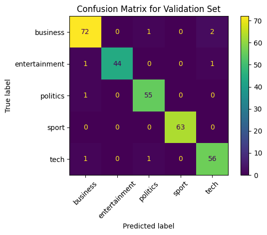

```
Training size: 10% - Validation Accuracy: 0.9362
Training size: 20% - Validation Accuracy: 0.9631
Training size: 50% - Validation Accuracy: 0.9631
Training size: 80% - Validation Accuracy: 0.9664
```

```python
param_grids = {
    "Random Forest": {
        "n_estimators": [50, 100],
        "max_depth": [None, 10, 20]
    },
    "Support Vector Classifier": {
        "C": [0.1, 1.0],
        "gamma": [0.01, 0.1],
        "kernel": ['rbf']
    }
}

base_models = {
    "Random Forest": RandomForestClassifier(random_state=42),
    "Support Vector Classifier": SVC(),
}

best_model = None
best_accuracy = 0

for name, model in base_models.items():
    grid = GridSearchCV(model, param_grids.get(name, {}), cv=3, scoring='accuracy')
    grid.fit(X_train_svd, y_train)
    preds = grid.predict(X_val_svd)
    accuracy = accuracy_score(y_val, preds)
    print(f"{name} Validation Accuracy: {accuracy:.4f}")
    if accuracy > best_accuracy:
        best_accuracy = accuracy
        best_model = grid.best_estimator_

# Predict on the validation set using the best model
y_val_pred = best_model.predict(X_val_svd)

# Create the confusion matrix
cm = confusion_matrix(y_val, y_val_pred, labels=best_model.classes_)

# Plot the confusion matrix
plt.figure(figsize=(10, 8))
disp = ConfusionMatrixDisplay(confusion_matrix=cm, display_labels=best_model.classes_)
disp.plot(xticks_rotation=45)
plt.title('Confusion Matrix for Validation Set')
plt.tight_layout()
plt.show()

for frac in [0.1, 0.2, 0.5,0.8]:
    X_sub, _, y_sub, _ = train_test_split(X_train_svd, y_train, train_size=frac, stratify=y_train, random_state=42)
    model = best_model
    model.fit(X_sub, y_sub)
    acc = accuracy_score(y_val, model.predict(X_val_svd))
    print(f"Training size: {int(frac*100)}% - Validation Accuracy: {acc:.4f}")
```

### Unsupervised Learning with Matrix Factorization

Here we will try to learn without using the label. Labels will be used to measure the accuracy of the model.

```
Unsupervised Training Accuracy: 0.8255
```

[figure not shown]

```python
# Avoid core counting warnings
os.environ['OMP_NUM_THREADS'] = '4'

# Encode labels as integers for comparison
le = LabelEncoder()
y_train_enc = le.fit_transform(y_train)

# Vectorize train text using TF-IDF
vectorizer_unsup = TfidfVectorizer(max_features=3000)
X_unsup_vec = vectorizer_unsup.fit_transform(X_train)

# Apply TruncatedSVD to discover latent topics
svd_unsup = TruncatedSVD(n_components=5, random_state=42)  # Start with 5 topics
X_unsup_svd = svd_unsup.fit_transform(X_unsup_vec)

# Use KMeans to assign cluster labels to articles
kmeans = KMeans(n_clusters=5, random_state=42)
unsup_preds_train = kmeans.fit_predict(X_unsup_svd)

# Map cluster labels to actual category labels via majority voting
cluster_to_label = {}
for cluster in range(5):
    idx = np.where(unsup_preds_train == cluster)
    majority_label = np.bincount(y_train_enc[idx]).argmax()
    cluster_to_label[cluster] = majority_label

mapped_preds_train = [cluster_to_label[cluster] for cluster in unsup_preds_train]

# Evaluate performance
acc_unsup_train = accuracy_score(y_train_enc, mapped_preds_train)
print(f"Unsupervised Training Accuracy: {acc_unsup_train:.4f}")

# Confusion Matrix
cm_unsup = confusion_matrix(y_train_enc, mapped_preds_train)
disp.plot(xticks_rotation=45)
plt.title('Confusion Matrix for Validation Set')
plt.tight_layout()
plt.show()
```

### Trying with more or less than 5 categories !

The data only has 5 categories but in reality, even those can be sub categorized or merged and represented in a different way. if we assume that those labels are not static, we can try to predict using more or less than 5 clusters.

```
Model does best with: 9 categories
```

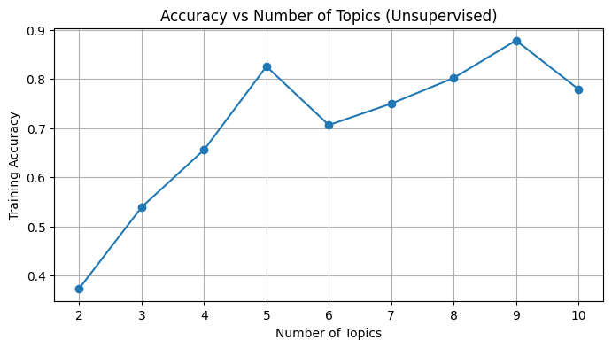

```python
results = []
macAcc = 0
kBest = 0

for k in range(2, 11):  # Try 2 to 10 topics
    svd_k = TruncatedSVD(n_components=k, random_state=42)
    X_svd_k = svd_k.fit_transform(X_unsup_vec)
    kmeans_k = KMeans(n_clusters=k, random_state=42)
    pred_k = kmeans_k.fit_predict(X_svd_k)

    mapping = {}
    for cluster in range(k):
        idx = np.where(pred_k == cluster)
        if len(idx[0]) == 0:
            continue
        majority_label = np.bincount(y_train_enc[idx]).argmax()
        mapping[cluster] = majority_label

    mapped_pred_k = [mapping.get(cluster, -1) for cluster in pred_k]
    acc_k = accuracy_score(y_train_enc, mapped_pred_k)
    results.append((k, acc_k))
    if acc_k > macAcc:
        macAcc = acc_k
        kBest = k

print("Model does best with:", str(kBest), "categories")

# Plot
ks, accs = zip(*results)
plt.figure(figsize=(8, 4))
plt.plot(ks, accs, marker='o')
plt.title('Accuracy vs Number of Topics (Unsupervised)')
plt.xlabel('Number of Topics')
plt.ylabel('Training Accuracy')
plt.xticks(ks)
plt.grid(True)
plt.show()
```

### Effect of sample size on unsupervised learning

Here, we will attempt to check the learning accuracy of the unsupervised model based on different sizes of training sets.

```
Training fraction: 10% - Unsupervised Accuracy: 0.7479
Training fraction: 20% - Unsupervised Accuracy: 0.7605
Training fraction: 50% - Unsupervised Accuracy: 0.7232
Training fraction: 80% - Unsupervised Accuracy: 0.8227
```

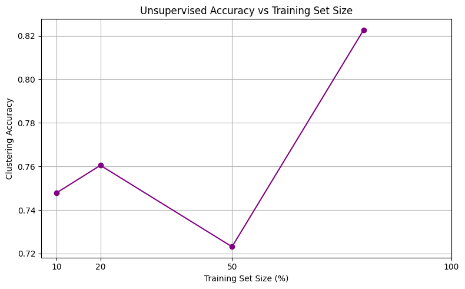

```python
fractions = [0.1, 0.2, 0.5, 0.8]
unsup_results = []

for frac in fractions:
    # Sample the data
    X_frac, y_frac = shuffle(X_train, y_train, random_state=42)
    sample_size = int(frac * len(X_frac))
    X_frac = X_frac[:sample_size]
    y_frac = y_frac[:sample_size]

    # Encode labels
    y_frac_enc = le.transform(y_frac)

    # Vectorize
    vec = TfidfVectorizer(max_features=3000)
    X_vec = vec.fit_transform(X_frac)

    # Topic modeling (TruncatedSVD)
    svd = TruncatedSVD(n_components=5, random_state=42)
    X_svd = svd.fit_transform(X_vec)

    # Clustering (KMeans)
    kmeans = KMeans(n_clusters=5, random_state=42)
    cluster_preds = kmeans.fit_predict(X_svd)

    # Map clusters to labels using majority voting
    cluster_to_label = {}
    for cluster in range(5):
        idx = np.where(cluster_preds == cluster)[0]
        if len(idx) > 0:
            majority_label = np.bincount(y_frac_enc[idx]).argmax()
            cluster_to_label[cluster] = majority_label

    mapped_preds = [cluster_to_label.get(cluster, -1) for cluster in cluster_preds]
    acc = accuracy_score(y_frac_enc, mapped_preds)
    unsup_results.append((frac, acc))
    print(f"Training fraction: {int(frac*100)}% - Unsupervised Accuracy: {acc:.4f}")

# Plot accuracy vs training size
frac_vals, acc_vals = zip(*unsup_results)

plt.figure(figsize=(8, 5))
plt.plot([int(f*100) for f in frac_vals], acc_vals, marker='o', color='purple')
plt.title('Unsupervised Accuracy vs Training Set Size')
plt.xlabel('Training Set Size (%)')
plt.ylabel('Clustering Accuracy')
plt.xticks([10, 20, 50, 100])
plt.grid(True)
plt.tight_layout()
plt.show()
```